# White Wine EDA

George Vince

August 1, 2017

# Packages used:

```r
library(dplyr)
library(ggplot2)
library(gridExtra)
library(grid)
library(corrplot)
library(RColorBrewer)
```

# Introduction

This is my brief analysis into the physicochemical properties of white wine, and the influences it causes on the quality of the wine. A number of correlations and causes have been analysed and summarised at the end of each report section. Firstly I explored each variable and the distribution within in the dataset, before beginning univariate and bivariate analysis.

# Structure of data

```r
wine = read.csv("wineQualityWhites.csv")
names(wine)
```

```
##  [1] "X"                    "fixed.acidity"        "volatile.acidity"
##  [4] "citric.acid"          "residual.sugar"       "chlorides"
##  [7] "free.sulfur.dioxide"  "total.sulfur.dioxide" "density"
## [10] "pH"                   "sulphates"            "alcohol"
## [13] "quality"
```

```r
str(wine)
```

```
## 'data.frame':    4898 obs. of  13 variables:
##  $ X                   : int  1 2 3 4 5 6 7 8 9 10 ...
##  $ fixed.acidity       : num  7 6.3 8.1 7.2 7.2 8.1 6.2 7 6.3 8.1 ...
##  $ volatile.acidity    : num  0.27 0.3 0.28 0.23 0.23 0.28 0.32 0.27 0.3 0.22 ...
##  $ citric.acid         : num  0.36 0.34 0.4 0.32 0.32 0.4 0.16 0.36 0.34 0.43 ...
##  $ residual.sugar      : num  20.7 1.6 6.9 8.5 8.5 6.9 7 20.7 1.6 1.5 ...
##  $ chlorides           : num  0.045 0.049 0.05 0.058 0.058 0.05 0.045 0.045 0.049 0.044 ...
##  $ free.sulfur.dioxide : num  45 14 30 47 47 30 30 45 14 28 ...
##  $ total.sulfur.dioxide: num  170 132 97 186 186 97 136 170 132 129 ...
##  $ density             : num  1.001 0.994 0.995 0.996 0.996 ...
##  $ pH                  : num  3 3.3 3.26 3.19 3.19 3.26 3.18 3 3.3 3.22 ...
##  $ sulphates           : num  0.45 0.49 0.44 0.4 0.4 0.44 0.47 0.45 0.49 0.45 ...
##  $ alcohol             : num  8.8 9.5 10.1 9.9 9.9 10.1 9.6 8.8 9.5 11 ...
##  $ quality             : int  6 6 6 6 6 6 6 6 6 6 ...
```

```r
# Remove index number, as it's no use
wine$X = NULL
summary(wine)
```

```
##  fixed.acidity    volatile.acidity  citric.acid     residual.sugar
##  Min.   : 3.800   Min.   :0.0800   Min.   :0.0000   Min.   : 0.600
##  1st Qu.: 6.300   1st Qu.:0.2100   1st Qu.:0.2700   1st Qu.: 1.700
##  Median : 6.800   Median :0.2600   Median :0.3200   Median : 5.200
##  Mean   : 6.855   Mean   :0.2782   Mean   :0.3342   Mean   : 6.391
##  3rd Qu.: 7.300   3rd Qu.:0.3200   3rd Qu.:0.3900   3rd Qu.: 9.900
##  Max.   :14.200   Max.   :1.1000   Max.   :1.6600   Max.   :65.800
##    chlorides       free.sulfur.dioxide total.sulfur.dioxide
##  Min.   :0.00900   Min.   :  2.00      Min.   :  9.0
##  1st Qu.:0.03600   1st Qu.: 23.00      1st Qu.:108.0
##  Median :0.04300   Median : 34.00      Median :134.0
##  Mean   :0.04577   Mean   : 35.31      Mean   :138.4
##  3rd Qu.:0.05000   3rd Qu.: 46.00      3rd Qu.:167.0
##  Max.   :0.34600   Max.   :289.00      Max.   :440.0
##     density             pH          sulphates         alcohol
##  Min.   :0.9871   Min.   :2.720   Min.   :0.2200   Min.   : 8.00
##  1st Qu.:0.9917   1st Qu.:3.090   1st Qu.:0.4100   1st Qu.: 9.50
##  Median :0.9937   Median :3.180   Median :0.4700   Median :10.40
##  Mean   :0.9940   Mean   :3.188   Mean   :0.4898   Mean   :10.51
##  3rd Qu.:0.9961   3rd Qu.:3.280   3rd Qu.:0.5500   3rd Qu.:11.40
##  Max.   :1.0390   Max.   :3.820   Max.   :1.0800   Max.   :14.20
##     quality
##  Min.   :3.000
##  1st Qu.:5.000
##  Median :6.000
##  Mean   :5.878
##  3rd Qu.:6.000
##  Max.   :9.000
```

# Univariate Plots Section

Lets take a look at each of the variable histograms

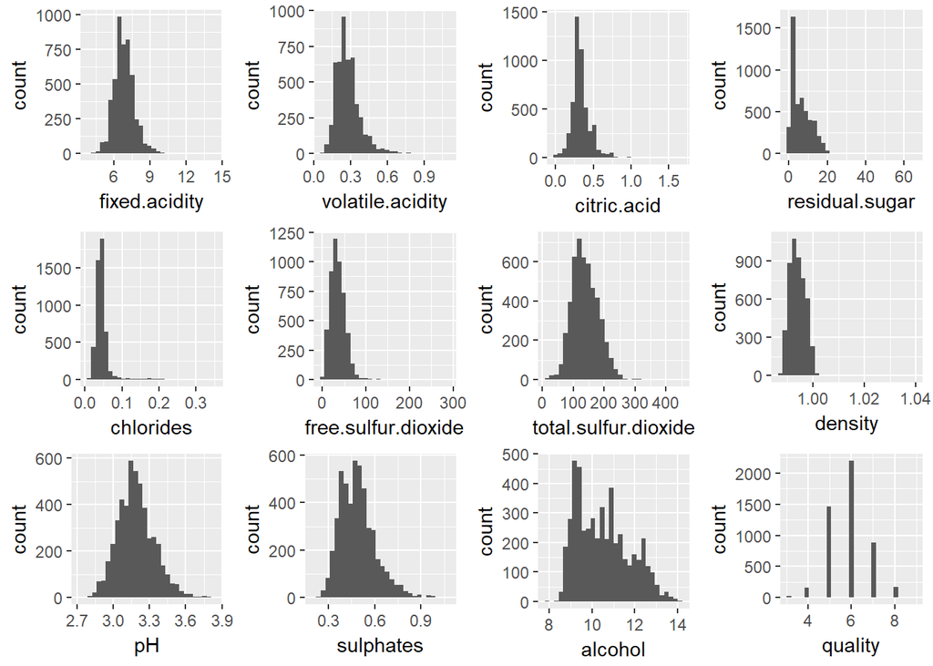

It appears that density and pH are normally distributed, with few outliers.

Fixed and volatile acidity, sulfur dioxides, sulphates, and alcohol seem to be long-tailed.

It seems, residual sugar, chlorides, density have extreme outliers.

Lets take a closer look at each of the variables below.

### Quality

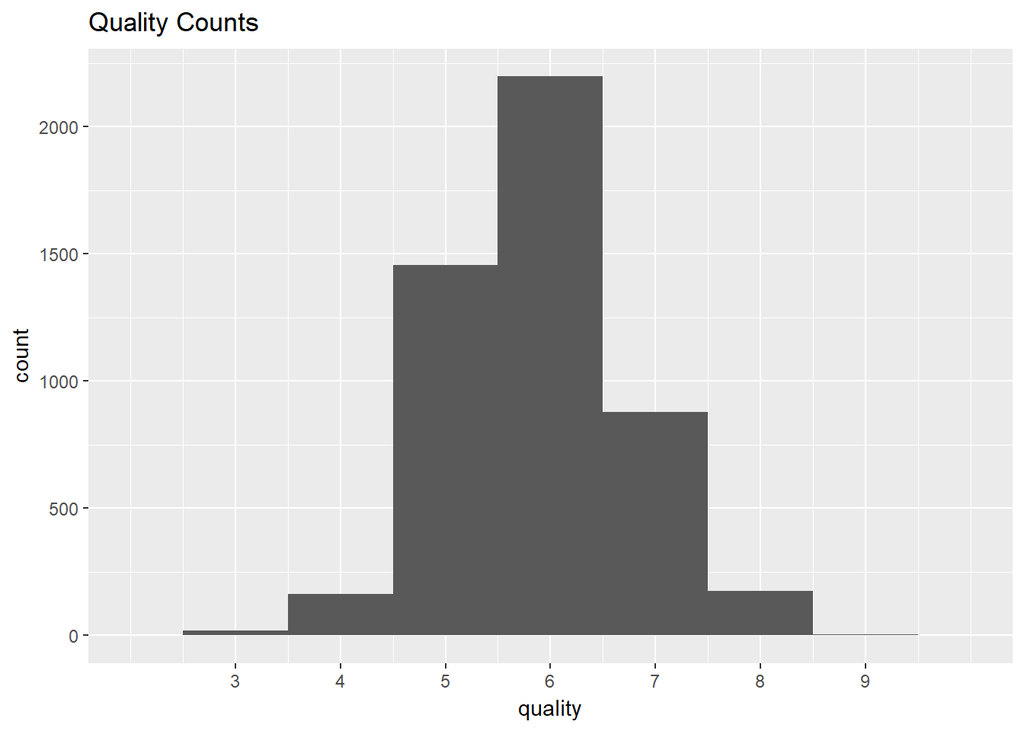

```
##
##    3    4    5    6    7    8    9
##   20  163 1457 2198  880  175    5
```

Here we can see quality ranges from 3 - 9, we don’t have much data (if any) for exceptionally good or bad wines.

Given the ratings and distribution of wine quality, I’ll create another categorical variable, classifying the wines as ‘bad’ (rating 0 to 4), ‘average’ (rating 5 - 7), and ‘excellent’ (rating 8 to 9). By splitting the data this way we have roughly the same amount of wines in our bad and excellent categories.

```r
wine$rating <- ifelse(wine$quality < 5, 'bad', ifelse(
  wine$quality < 8, 'average', 'excellent'))

wine$rating <- ordered(wine$rating,
                     levels = c('bad', 'average', 'excellent'))

summary(wine$rating)
```

```
##       bad   average excellent
##       183      4535       180
```

### Fixed Acidity

Viewing the histogram it shows that the majority of fixed acidities fall between 5.5 and 8.5.

```
##    Min. 1st Qu.  Median    Mean 3rd Qu.    Max.
##   3.800   6.300   6.800   6.855   7.300  14.200
```

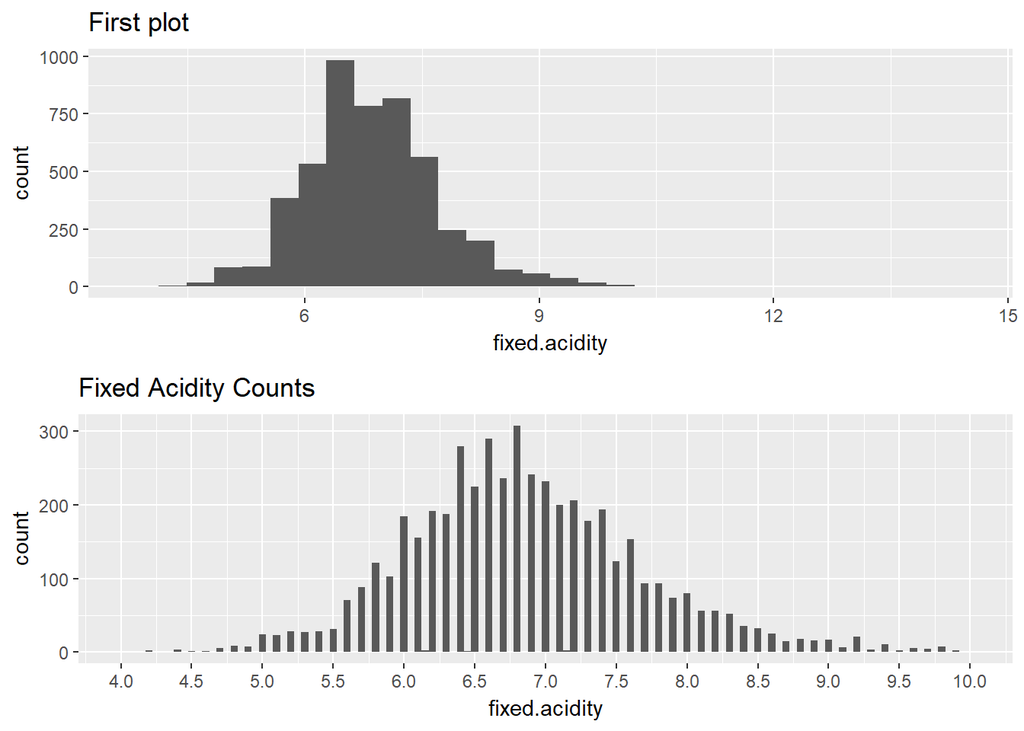

### volatile acidity

Volatile acidity produces a long tailed plot with most wines having an acetic value between 0.15 - 0.40. Its stated in the data description that high levels of acetic acid can cause a vinegary taste, I will see if this results in a poorer quality rating.

```
##    Min. 1st Qu.  Median    Mean 3rd Qu.    Max.
##  0.0800  0.2100  0.2600  0.2782  0.3200  1.1000
```

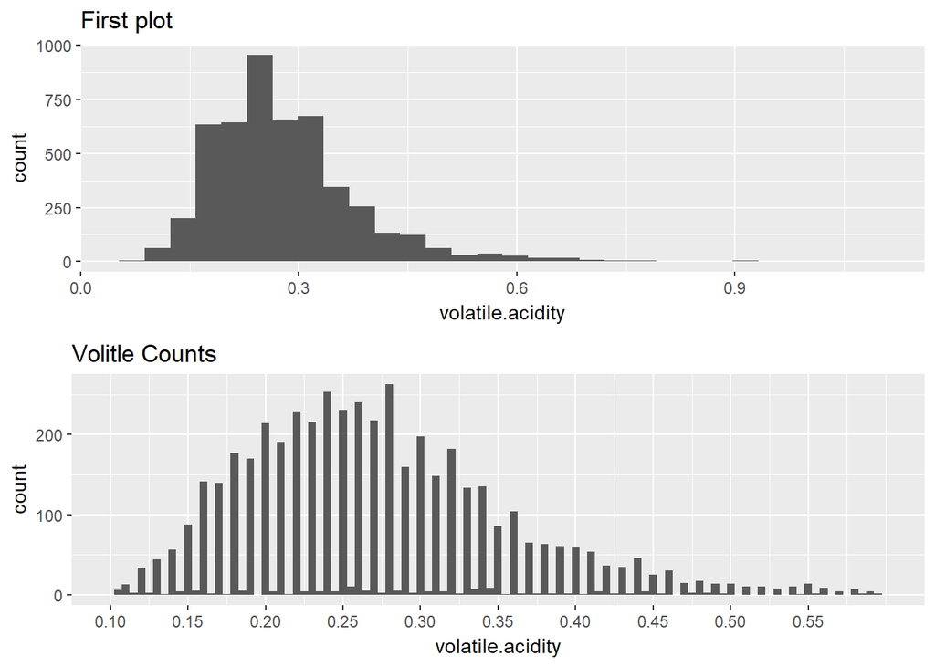

### Citric acid

Small quantities of citric acid can lead to “freshness is wine”. Most values fall between 0.20 - 0.45g/l Noticed an interesting spike at 0.49g/l

```
##    Min. 1st Qu.  Median    Mean 3rd Qu.    Max.
##  0.0000  0.2700  0.3200  0.3342  0.3900  1.6600
```

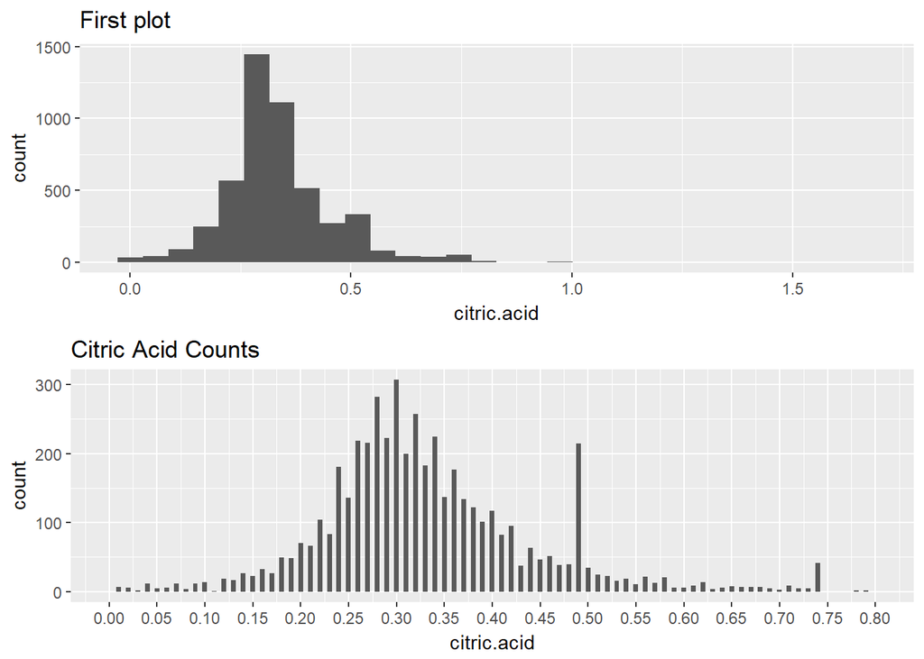

### Residual Sugar

It seems residual sugar has a large range, but most values fall between 1 - 20g/l.

```
##    Min. 1st Qu.  Median    Mean 3rd Qu.    Max.
##   0.600   1.700   5.200   6.391   9.900  65.800
```

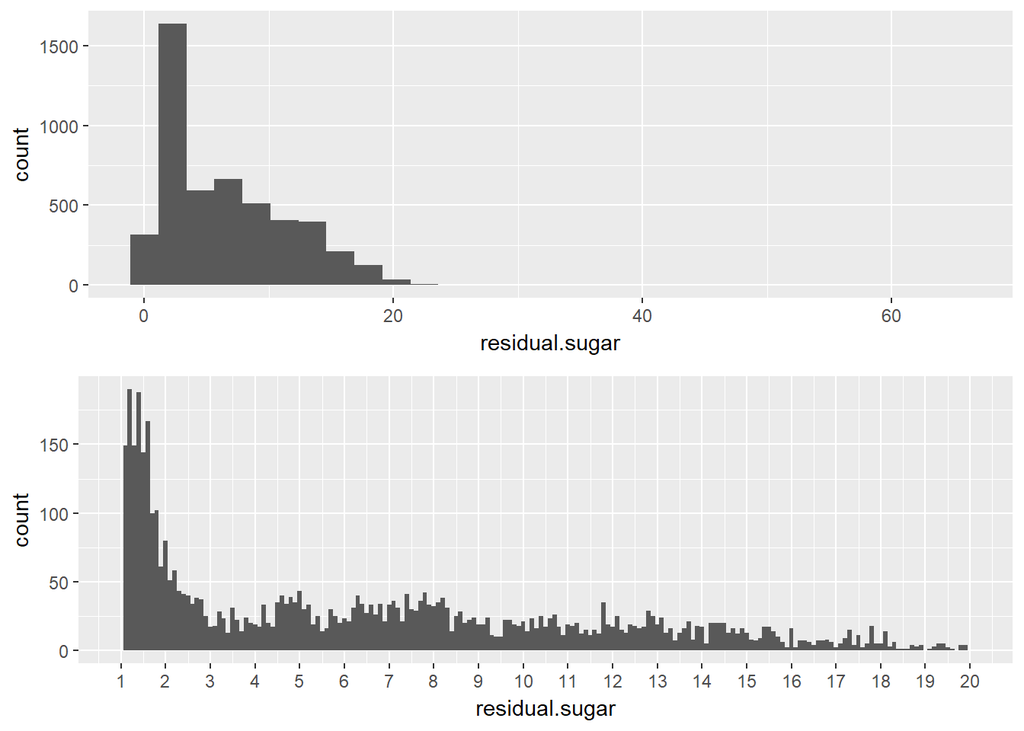

### Chlorides

Chlorides indicate the amount of salt in wine, it seems normally distributed.

```
##    Min. 1st Qu.  Median    Mean 3rd Qu.    Max.
## 0.00900 0.03600 0.04300 0.04577 0.05000 0.34600
```

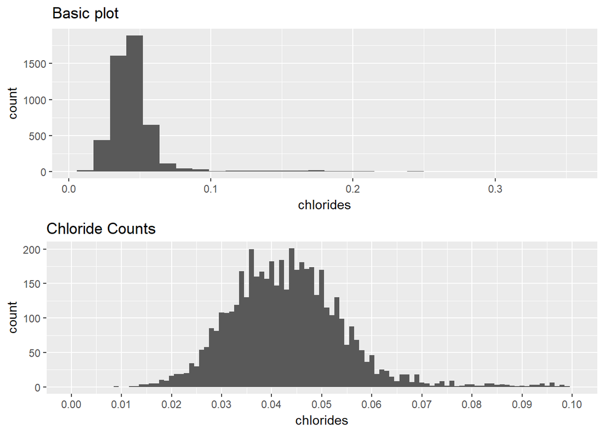

### Free sulfur dioxide

```
##    Min. 1st Qu.  Median    Mean 3rd Qu.    Max.
##    2.00   23.00   34.00   35.31   46.00  289.00
```

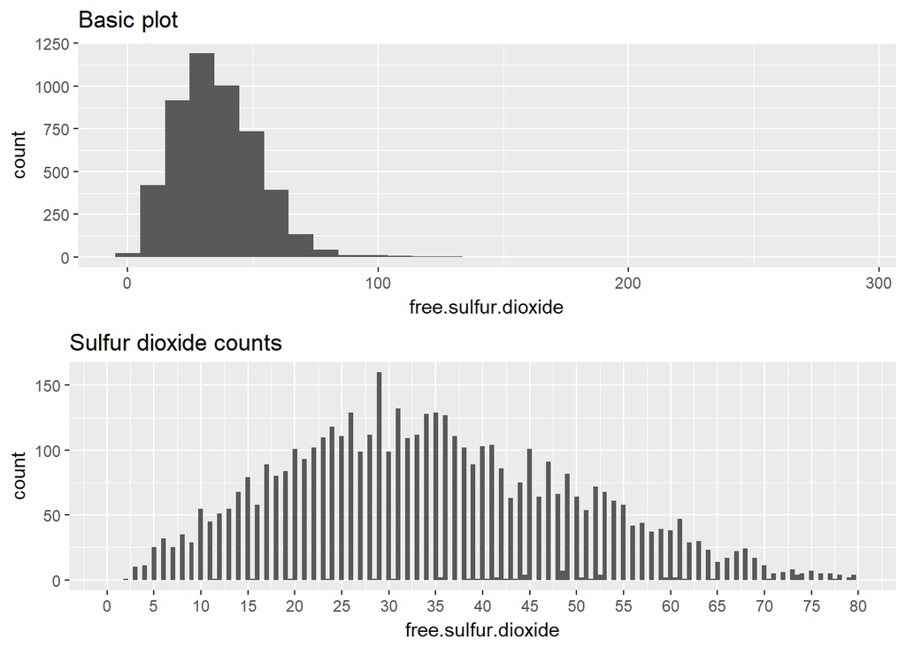

According to the data description “at free SO2 concentrations over 50 ppm, SO2 becomes evident in the nose and taste of wine”, so I have created a variable free.sulfur.dioxide.cat as “noticeable” (free.sulfur.dioxide > 50) and “not noticeable” (free.sulfur.dioxide <= 50).

```r
wine$free.sulfur.dioxide.cat <- ifelse(wine$free.sulfur.dioxide > 50,
                                       'noticeable', 'not noticeable' )

table(wine$free.sulfur.dioxide.cat)
```

```
##
## not noticeable     noticeable
##           4030            868
```

### Total sulfur dioxide

```
##    Min. 1st Qu.  Median    Mean 3rd Qu.    Max.
##     9.0   108.0   134.0   138.4   167.0   440.0
```

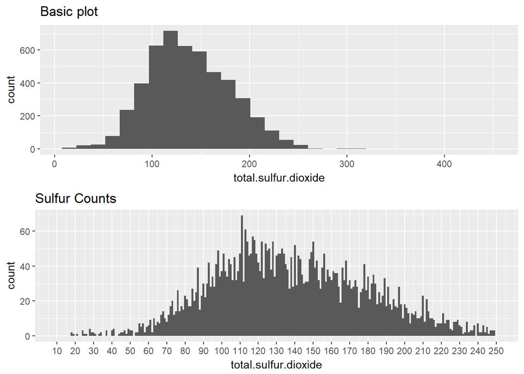

### Density

Density is normally distributed with most values falling between 0.9 - 1g /ml; Density is directly affected by water and alcohol percentage

```
##    Min. 1st Qu.  Median    Mean 3rd Qu.    Max.
##  0.9871  0.9917  0.9937  0.9940  0.9961  1.0390
```

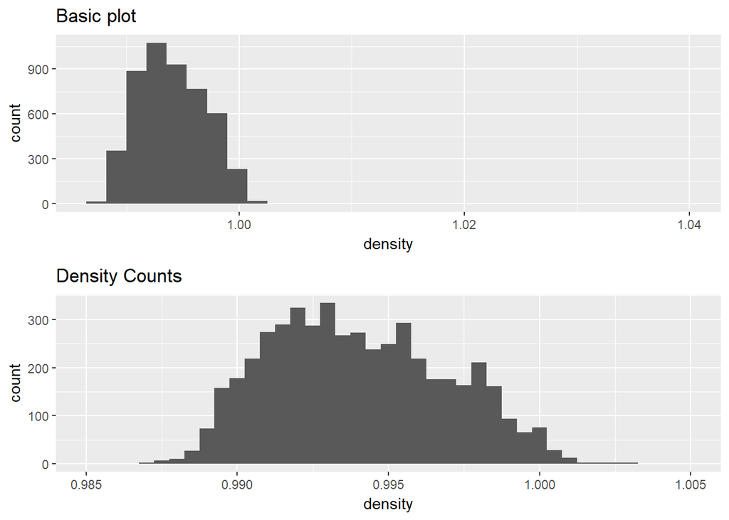

### PH

PH Seems to normally distributed and vary from 2.7 - 3.8. This indicates that white wines are always acidic.

```
##    Min. 1st Qu.  Median    Mean 3rd Qu.    Max.
##   2.720   3.090   3.180   3.188   3.280   3.820
```

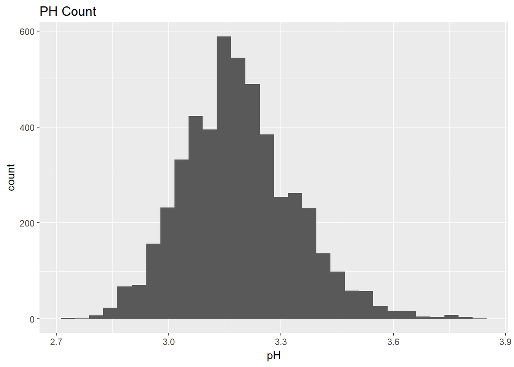

### Sulphates

Sulphates have a mostly normal distribution which is slightly positively skewed with few outliers.

```
##    Min. 1st Qu.  Median    Mean 3rd Qu.    Max.
##  0.2200  0.4100  0.4700  0.4898  0.5500  1.0800
```

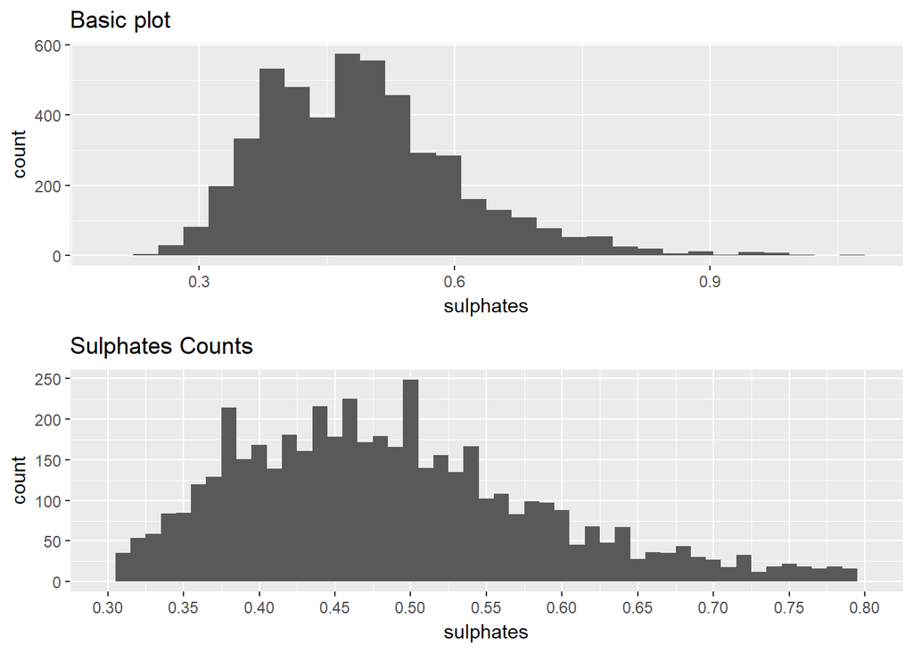

### Alcohol

Distribution of variable alcohol is positively skewed. Most of the values are between 9% and 13%.

```
##    Min. 1st Qu.  Median    Mean 3rd Qu.    Max.
##    8.00    9.50   10.40   10.51   11.40   14.20
```

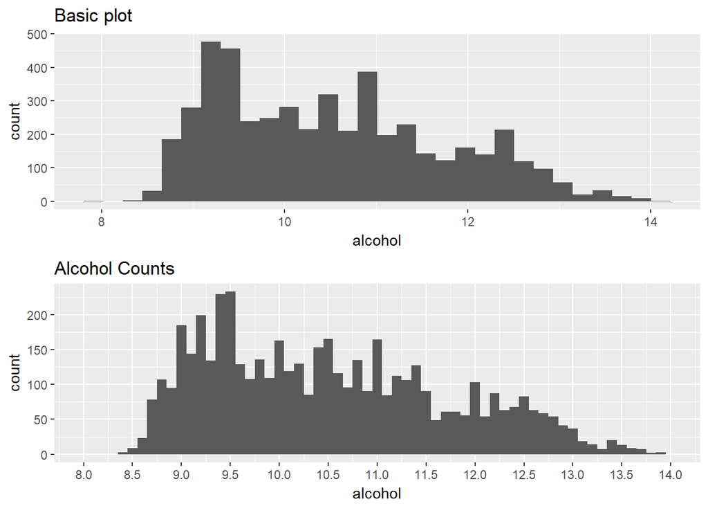

# Univariate Analysis

### What is the structure of your dataset?

My dataset is related to the quality of white wine. The dataset is already tidy with observation mentioning the physicochemical properties of the wine. There are 4898 observations of 13 variables. The variable ‘quality’ is based on the median rating by 3 wine experts. The other physicochemical variables are fixed.acidity, volatile.acidity, citric.acid, residual.sugar, chlorides, free.sulfur.dioxide, total.sulfur.dioxide, density, pH, sulphates and alcohol.

The quality variable can be seen as factor variable with 0 to 10 i.e. 11 possible levels, where only 7 levels are present in dataset i.e . 3-9.

It’s important to note that only physicochemical variables are available, there is no data on other variables such as grape type, wine brand, wine selling price etc.

### What is/are the main feature(s) of interest in your dataset?

I’m interested to see if any of the variables produce consistently good, or bad white wine.

### Did you create any new variables from existing variables in the dataset?

Binned values in the quality column, providing me with a range of bad, average and excellent wines. I also created a variable to highlight if free bound SO2 levels were noticeable in the wine or not.

# Bivariate Plots Section

Lets examine the corrolation matrix

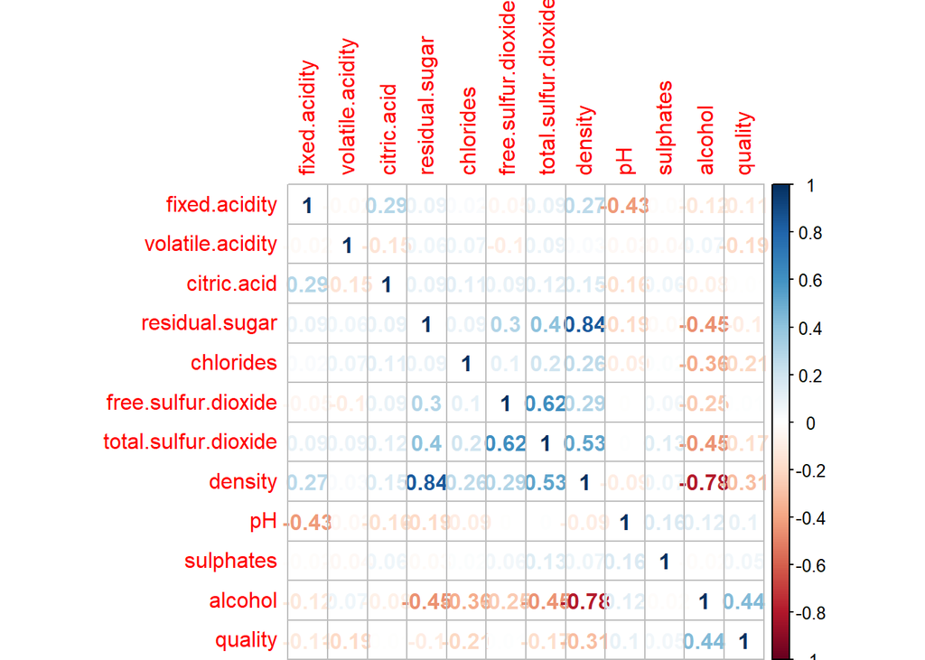

Key factors that seem to have correlation with quality of wine are density and alcohol.

I’m also going to examine the corolations between density and residual sugar and the relationship between sulfur dioxides.

pH is also negatively corrolated with fixed acidity, I feel like this is obvious and doesn’t need investigating much further.

## Density

Lets look at the two highest correlating variables with density. It looks like density is correlated negatively alcohol, and positively with residual sugar amounts. I think intuitively this should be correct as more sugar would result in an increase in density, and vice versa for alcohol amounts.

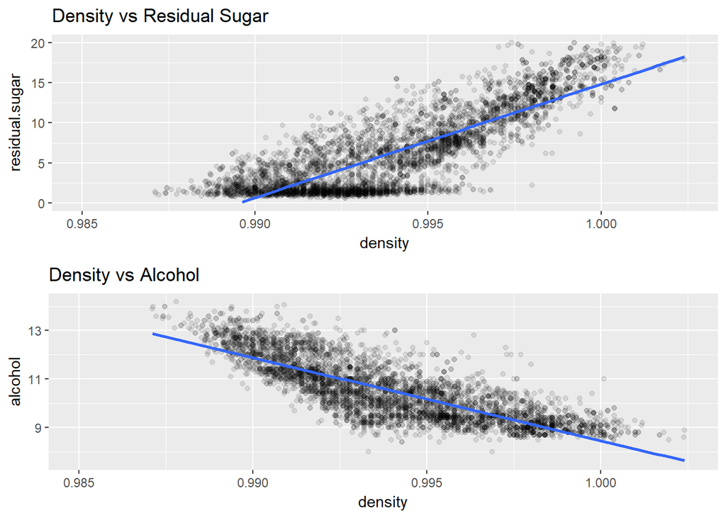

## Citric Acid

I noticed a peak at 0.49g / l, I’m going to see if these wines had any higher quality then all other wines. Perhaps this is the sweet spot for a fresh tasting wine?

```r
wine %>% group_by(citric.acid == 0.49) %>%
    summarise(mean(quality), count = n())
```

```
## # A tibble: 2 x 3
##   `citric.acid == 0.49` `mean(quality)` count
##                   <lgl>           <dbl> <int>
## 1                 FALSE        5.877215  4683
## 2                  TRUE        5.893023   215
```

Hmm, perhaps not worth investigating this as there is no noticeable increase in quality.

## Volatile Acidity

The data description states that high levels of acetic acid can lead to a vinegar taste. It seems like this holds true as our lower quality wine have a higher acidity level.

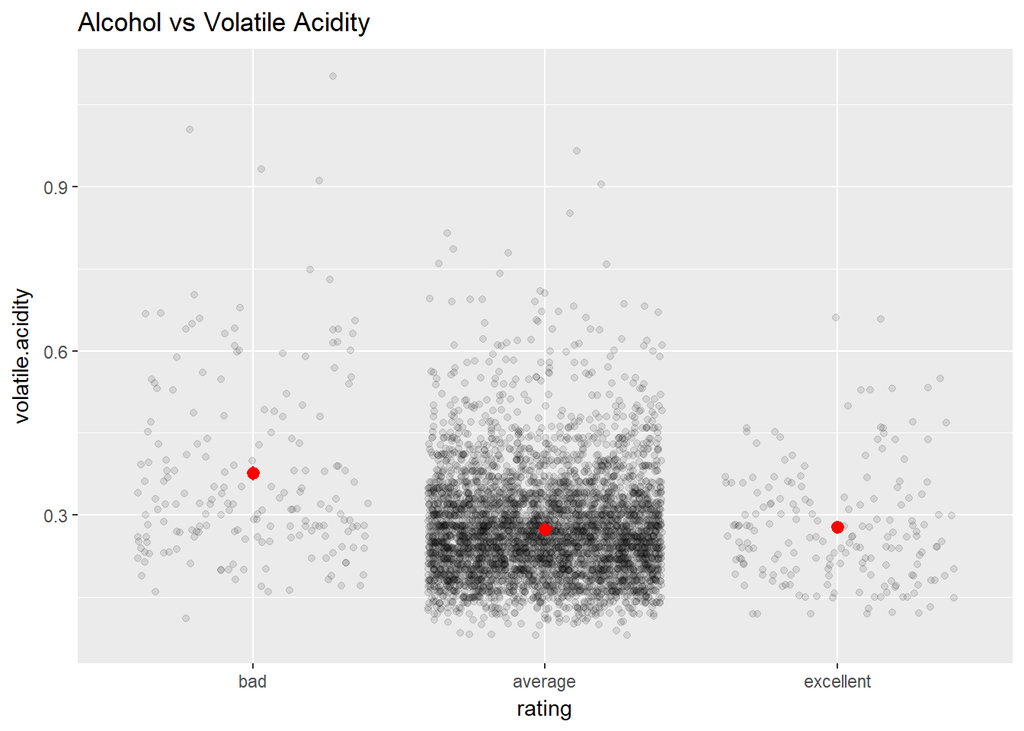

```r
p1 <- ggplot(wine, aes(rating, volatile.acidity)) +
  geom_jitter(alpha = 0.1) +
  stat_summary(color = 'red') +
  ggtitle("Alcohol vs Volatile Acidity ")

p1
```

```r
wine %>% group_by(rating) %>%
    summarise(Mean_Volitile_Acdity = mean(volatile.acidity), count = n())
```

```
## # A tibble: 3 x 3
##      rating Mean_Volitile_Acdity count
##       <ord>                <dbl> <int>
## 1       bad            0.3759836   183
## 2   average            0.2743076  4535
## 3 excellent            0.2779722   180
```

## Alcohol

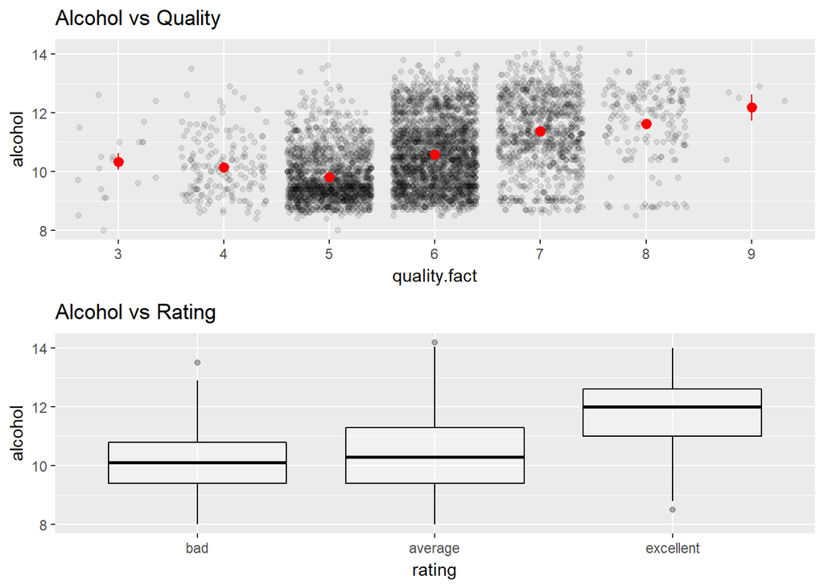

```
## # A tibble: 3 x 3
##      rating `mean(alcohol)` `median(alcohol)`
##       <ord>           <dbl>             <dbl>
## 1       bad        10.17350              10.1
## 2   average        10.48290              10.3
## 3 excellent        11.65111              12.0
```

# Bivariate Analysis

### Talk about some of the relationships you observed in this part of the investigation. How did the feature(s) of interest vary with other features in the dataset?

- I’ve explored the relationship between alcohol content and wine rating, it seems that higher scoring wines tended to have a higher alcohol content.
- Density seems to decrease with alcohol percentage
- Density increases as residual sugar levels increase
- Lower quality wines seem to have a higher acetic acid content.

### What was the strongest relationship you found?

According to our correlation plot, density was strongly correlated with sugar and alcohol content levels.

- Alcohol vs Wine QUality
- Alcohol vs Density
- Sugar vs Density

# Multivariate Plots Section

## Free sulphur

According to our correlation plot - free sulfur and quality are not correlated. Perhaps the if we take a look at noticeable amounts of free sulfur they can correlate with quality levels. Next up I compared the total sulfur to quality correlations.

```
## [1] "Full wine quality/ sulfur correlation: 0.0082"
```

```
## [1] "Not noticable sulfur / quality correlation: -0.1263"
```

```
## [1] "Noteiceable sulfur / quality correlation: -0.2935"
```

So when we have a noticeable amount of sulfur in the wine there is a stronger negative correlation between total sulfur and quality.

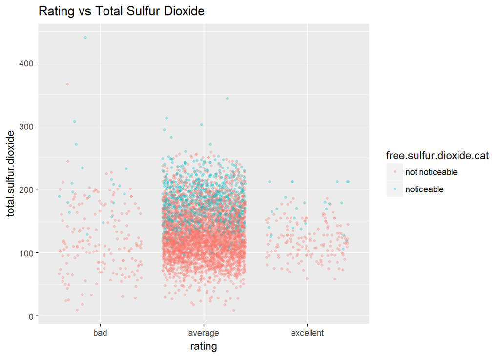

Total SO2 content is made up of free and bound sulfur content, it’s interesting to see how some wines have a higher total sulfur content but it is still not noticeable as I assume free sulfur dioxide levels remain below 50.

Lets explore how the noticeable free sulfur dioxide levels relate to alcohol and quality.

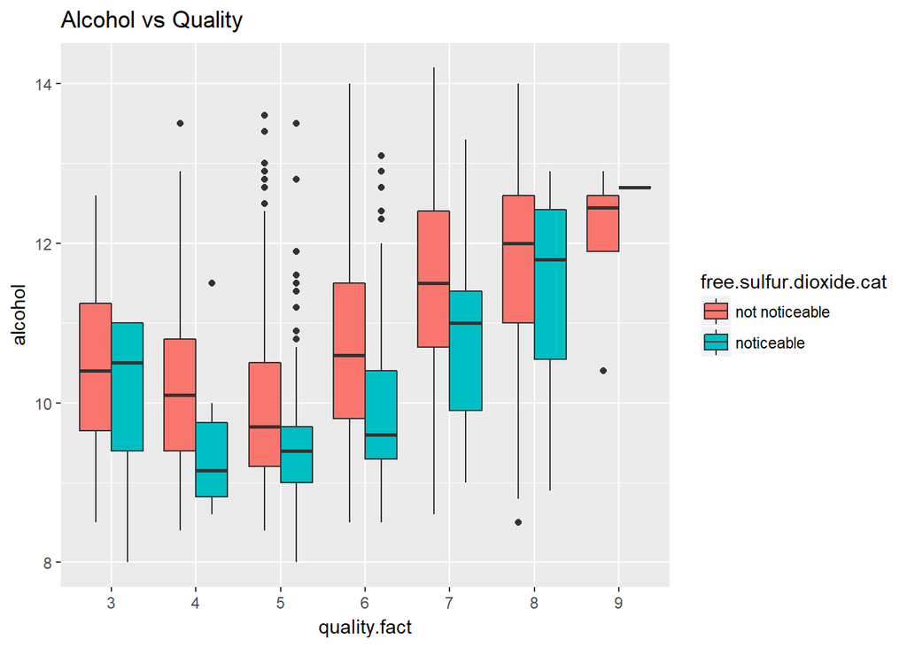

```
## # A tibble: 14 x 4
## # Groups:   quality.fact [?]
##    quality.fact free.sulfur.dioxide.cat `mean(alcohol)` count
##          <fctr>                   <chr>           <dbl> <int>
##  1            3          not noticeable       10.466667    15
##  2            3              noticeable        9.980000     5
##  3            4          not noticeable       10.227181   149
##  4            4              noticeable        9.357143    14
##  5            5          not noticeable        9.907894  1108
##  6            5              noticeable        9.494365   349
##  7            6          not noticeable       10.720852  1808
##  8            6              noticeable        9.900940   390
##  9            7          not noticeable       11.426017   795
## 10            7              noticeable       10.824706    85
## 11            8          not noticeable       11.690066   151
## 12            8              noticeable       11.295833    24
## 13            9          not noticeable       12.050000     4
## 14            9              noticeable       12.700000     1
```

It seems almost consistently wines with not noticeable sulfur levels have a higher alcohol content. A higher alcohol content is a key variable in leading to the quality of wine. Therefore if you’re looking to avoid sulfur, pick a wine with a higher alcohol content!

## Alcohol vs Volatile Acidity

We know wines with a higher alcohol percentage and lower acetic acid level tend to be a higher quality. Lets visualise this by looking at the “bad” and “excellent” wines in our data.

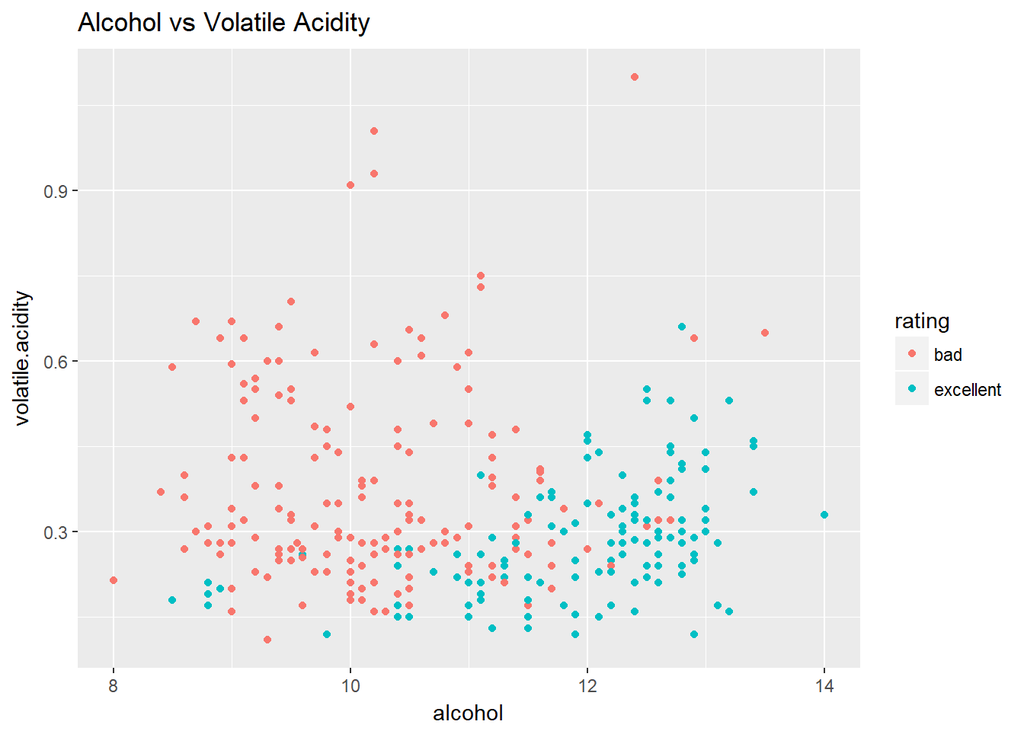

Straight away we can see that this holds true, most of our higher quality wines are in the bottom right of the graph showing they have a higher alcohol content and lower acetic acid level.

# Multivariate Analysis

Three key relationships were discovered here, firstly we looked at how the levels of SO2 in wine can have different total amounts yet still be undectable due to unnoticeable levels of SO2. Once SO2 levels were noticeabel there is a slight correlation between total SO2 levels and quality.

Next, we explored how white wines with a higher alcohol content generally have a lower level of total SO2.

Finally we explored two characteristics in white wine and how that higher quality white wines generally have lower volitile acid levels as well as a higher alcohol percentage.

# Final Plots and Summary

## Plot one

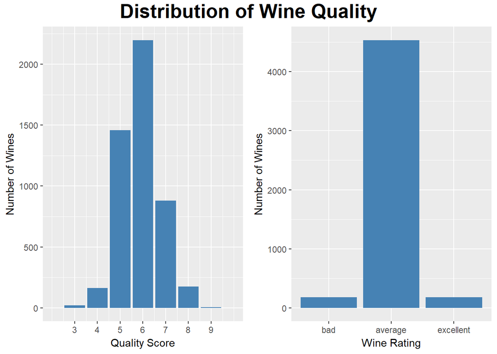

### Description One

The first final plot I’ve chosen highlights the distribution of wines within the dataset. It’s important to not there was not a balanced distribution of bad, excellent and average wines. This begs the question, is this the distribution for wines generally, or just for this dataset? The data also contained no entries for wines have a score of 1, 2 or 10 - I can see how this is possible as quality scores are defined as the mean from 3 expert opinions, making it difficult to achieve these scores.

## Plot Two

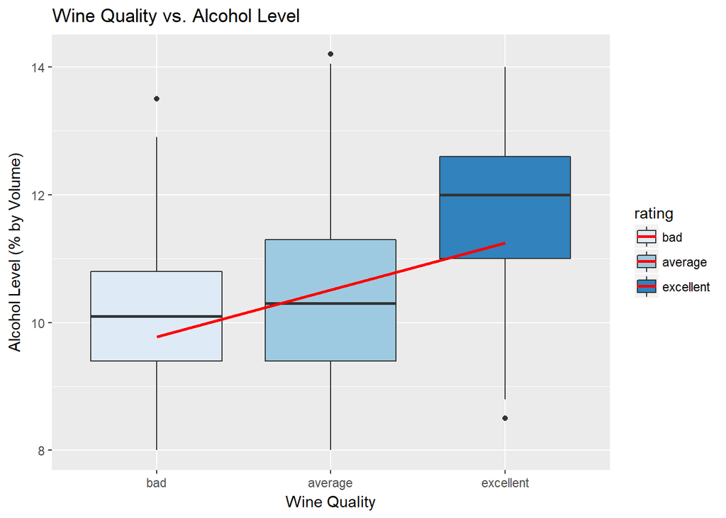

### Description Two

My next plot shows how a characteristic of excellent wine is having a higher alcohol percentage. This was the strongest correlation I found within my data of 0.44, however this is not particularly strong so should not be used as the primary indicator in white wine quality.

## Plot Three

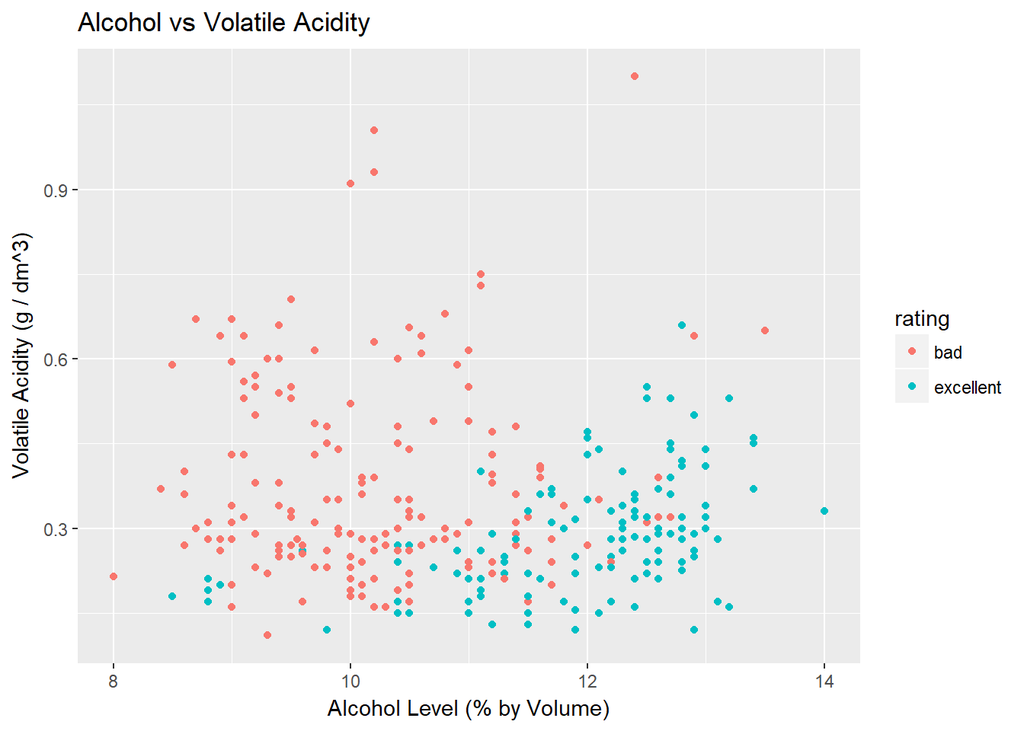

### Description Three

During the multivariant analysis I discovered that higher quality wines tended to have a higher alcohol content as well as a lower volatile acidity content. It’s possible that his has a synergistic effect on the taste of the wine as a higher alcohol percentage could also mask the acidity taste from wine.

# Reflection

I feel that wine quality is decided by many independent factors, it is very difficult to distinguish wine quality just by combinding of two factors. Also, a large number of factors were not present in this data that could have accounted for a change in quality such as wine price, brand or grape type. This dataset had limited data on excellent and poorer qualities of wines, making it difficult to produce a representative analysis. Findings from this analysis can only be generalised to the Portuguese “Vinho Verde” wine, it’s very likely that different types of white wine will have varyingly different factors that conttribute towards quality.

In terms of future work, two ideas spring to mind. A data set is also available for the red version if the Vinho Verde wine, it would be interesting to explore the factors that cause success is red wine and perhaps compare these findings to results found from this report. It may also be worth trying to find a dataset that contains other factors, such as price and grape type as I have a feeling there are a number of other factors that make up the quality of a wine.

A second idea I had is performing some research into machine learning, for example - given a set of wine properties, can we accurately predict the quality of wine? I’m sure I’m going to cover this on my next module - “Introduction to Machine Learning”!

During the project I encountered a number of issues; firstly with not being familar with the R programming language, lots of knowledge was obtained from Stackoverflow and various pages of the R documentation. Having the dataset already in a tidy format saved lots of hours wrangling, I think for more of a challenge next time I will source a dataset that encourages more data maniuplation and wragling before analysis can begin.

A second issue that cropped up was that there was not a very strong correlation between wine quality and one single variable - rather it was the combination of variables that caused an increase in wine quality. By exploring alcohol and acidity levels together I managed to find out a combination of variables that have an impact on wine quality.

# References

https://s3.amazonaws.com/udacity-hosted-downloads/ud651/wineQualityInfo.txt